# R for Applied Economists: Session 4

# Today’s plan

- catch up on yesterday
- debugger (from session 2)
- R/LaTeX integration
- tidying data
- graphs

# Tidying dat with the tidyr package

Tidy data is data where:

- each variable forms a column
- each observation is a row
- each type of observational unit forms a table

Here’s some data on patients heart rates under two different drug regimes. It’s shown three ways, the first two ‘messy’ and the third tidy.

```r
messy
```

```
##      name  a  b
## 1  Wilbur 67 56
## 2 Petunia 80 90
## 3 Gregory 64 50
```

```r
messy2
```

```
##   Drug Wilbur Petunia Gregory
## 1    a     67      80      64
## 2    b     56      90      50
```

```r
tidy
```

```
##      name drug heartrate
## 1  Wilbur    a        67
## 2 Petunia    a        80
## 3 Gregory    a        64
## 4  Wilbur    b        56
## 5 Petunia    b        90
## 6 Gregory    b        50
```

Three common problems with data:

1. Column headers are values, not variable names
2. Multiple variables in one column
3. Variables in *both* rows and columns

The ‘tidyr’ provides three functions which can be used (sometimes in combination) to solvethese problems:

- `gather()` takes multiple columns, and gathers them into key-value pairs: it makes *wide* data longer.
- `spread()` takes two columns (key & value) and spreads in to multiple columns, it makes *long* data wider.
- `seperate()` take one column and splits it into multiple columns

So we can solve the problems as follows:

1. Column headers are values, not variable names -> gather()
2. Multiple variables in one column -> seperate()
3. Variables in *both* rows and columns -> gather(), seperate() and then spread()

Gather:

```r
library(dplyr)
library(tidyr)

a <- data.frame(
    subjects =  c("John", "Jane", "Jill"),
    before =  c(3,9,5),
    after  =  c(4,10,12)
  )

a
```

```
##   subjects before after
## 1     John      3     4
## 2     Jane      9    10
## 3     Jill      5    12
```

```r
gather(a, period, income, before:after) #use dplyr's column selection syntax
```

```
##   subjects period income
## 1     John before      3
## 2     Jane before      9
## 3     Jill before      5
## 4     John  after      4
## 5     Jane  after     10
## 6     Jill  after     12
```

Another example:

```r
pew <- tbl_df(
  read.csv("http://git.io/AkBW")
)
pew
```

```
## Source: local data frame [18 x 11]
##
##                   religion X..10k X.10.20k X.20.30k X.30.40k X.40.50k
## 1                 Agnostic     27       34       60       81       76
## 2                  Atheist     12       27       37       52       35
## 3                 Buddhist     27       21       30       34       33
## 4                 Catholic    418      617      732      670      638
## 5    Don\222t know/refused     15       14       15       11       10
## 6         Evangelical Prot    575      869     1064      982      881
## 7                    Hindu      1        9        7        9       11
## 8  Historically Black Prot    228      244      236      238      197
## 9        Jehovah's Witness     20       27       24       24       21
## 10                  Jewish     19       19       25       25       30
## 11           Mainline Prot    289      495      619      655      651
## 12                  Mormon     29       40       48       51       56
## 13                  Muslim      6        7        9       10        9
## 14                Orthodox     13       17       23       32       32
## 15         Other Christian      9        7       11       13       13
## 16            Other Faiths     20       33       40       46       49
## 17   Other World Religions      5        2        3        4        2
## 18            Unaffiliated    217      299      374      365      341
## Variables not shown: X.50.75k (int), X.75.100k (int), X.100.150k (int),
##   X.150k (int), Don.t.know.refused (int)
```

```r
gather(pew, range, frequency, X..10k:Don.t.know.refused)
```

```
## Source: local data frame [180 x 3]
##
##                   religion  range frequency
## 1                 Agnostic X..10k        27
## 2                  Atheist X..10k        12
## 3                 Buddhist X..10k        27
## 4                 Catholic X..10k       418
## 5    Don\222t know/refused X..10k        15
## 6         Evangelical Prot X..10k       575
## 7                    Hindu X..10k         1
## 8  Historically Black Prot X..10k       228
## 9        Jehovah's Witness X..10k        20
## 10                  Jewish X..10k        19
## ..                     ...    ...       ...
```

Seperate:

```r
a <- data.frame(
     SessionRoom = c(paste("Morning", 1:3,sep=":"), paste("Evening", 1:3,sep=":")),
     outcome = sample(6)
)

a
```

```
##   SessionRoom outcome
## 1   Morning:1       5
## 2   Morning:2       3
## 3   Morning:3       1
## 4   Evening:1       2
## 5   Evening:2       6
## 6   Evening:3       4
```

```r
separate(data = a, col = SessionRoom, into = c("Time","Room"), sep=":")
```

```
##      Time Room outcome
## 1 Morning    1       5
## 2 Morning    2       3
## 3 Morning    3       1
## 4 Evening    1       2
## 5 Evening    2       6
## 6 Evening    3       4
```

Spread:

```r
 results <- data.frame(
     Individual = 1:5,
     Treatment = rep(c("A", "B","C","D"), each = 5),
     value = sample(20)
   )

spread(results,Treatment,value)
```

```
##   Individual  A  B  C  D
## 1          1 13  4  6 10
## 2          2  2  7 20 17
## 3          3  1 11  5  3
## 4          4 16  8 12 18
## 5          5  9 14 19 15
```

# Exercise: How does this work?

```r
library(dplyr)
```

```r
#create a nasty dataset
a <- data.frame(
        cbind(familyid = (1:3),
              name_father = c("Bill","Art","Paul"),
              income_father = c(30000,22000,25000),
              name_mother = c("Bess","Amy","Pat"),
              income_mother=c(15000,18000,50000)
              ),
        stringsAsFactors = F
     )

gathered   <- gather(a,key,value,name_father:income_mother)
seperated  <- separate(gathered,key,c("what","who"),sep="_")
tidy <- spread(seperated,what,value)
```

# broom package

Provides a nice way of getting a regression output into a data frame

```r
#install.packages("broom")
library(broom)
lmfit <- lm(mpg ~ wt, mtcars)
tidy(lmfit) #returns a data frame
```

```
##          term  estimate std.error statistic      p.value
## 1 (Intercept) 37.285126  1.877627 19.857575 8.241799e-19
## 2          wt -5.344472  0.559101 -9.559044 1.293959e-10
```

```r
#could now add a column:
tidy(lmfit) %>%
     mutate(model = "OLS")
```

```
##          term  estimate std.error statistic      p.value model
## 1 (Intercept) 37.285126  1.877627 19.857575 8.241799e-19   OLS
## 2          wt -5.344472  0.559101 -9.559044 1.293959e-10   OLS
```

# Exercise - what does this code do?

```r
doOLS <- function(i) {
                x <- rnorm(50)
                y <- 0.6 + 1*x + rnorm(50)
                tidy(lm(y ~ x)) %>%
                  mutate(i = i)
             }

hundred_OLS <- lapply(1:100, doOLS)
results <- do.call(rbind,hundred_OLS)
```

# Graphing

As is so often the case, there are multiple packages for doing graphs in R. There is base functionality, which hardly anyone seems to use, and then two main contenders: ggplot2 and lattice. Here’s a quick look at ggplot2. It provides to main features, qplot() and ggplot(). For most things, you can get by with qplot. Have a look at http://ggplot2.org/book/qplot.pdf for a nice introduction.

```r
library(ggplot2)
```

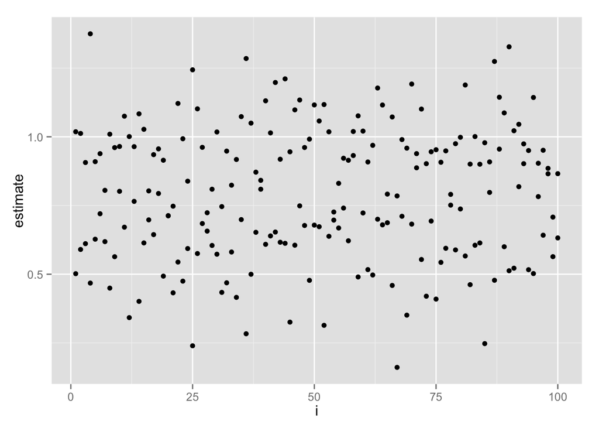

```r
qplot(x = i, y = estimate, data = results)
```

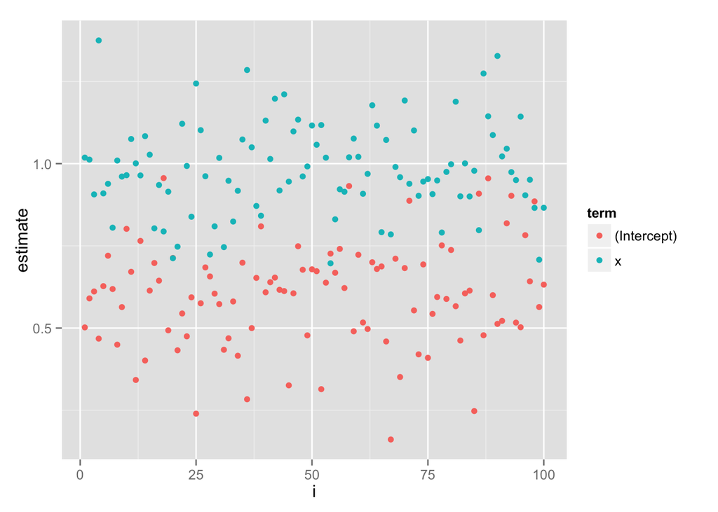

```r
qplot(i, estimate, color = term, data = results)
```

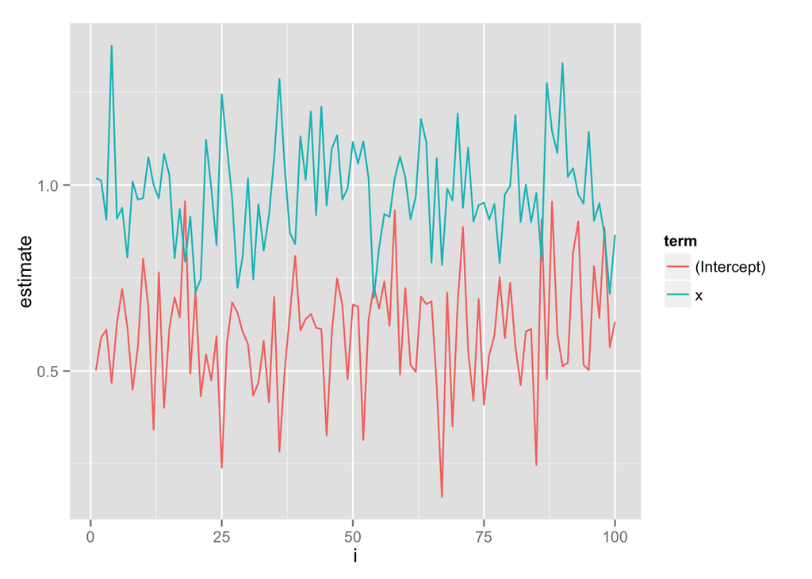

```r
qplot(i, estimate, color = term, data = results, geom = "line" )
```

```
## geom_smooth: method="auto" and size of largest group is <1000, so using loess. Use 'method = x' to change the smoothing method.
```

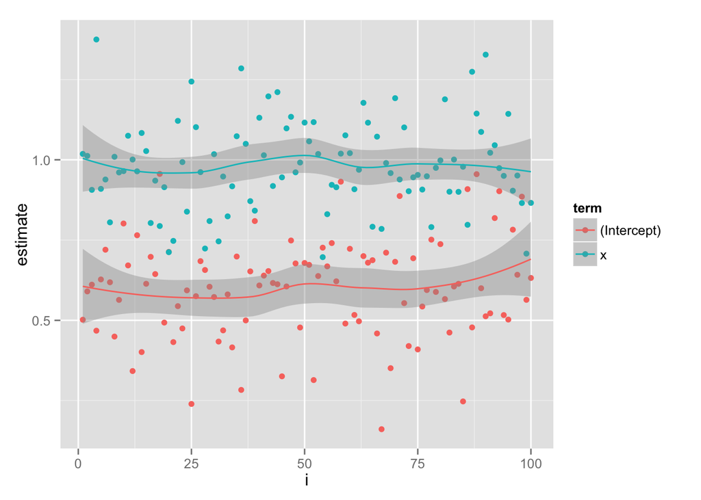

```r
qplot(i, estimate, color = term, data = results, geom = c("point","smooth" ))
```

```
## geom_smooth: method="auto" and size of largest group is <1000, so using loess. Use 'method = x' to change the smoothing method.
```

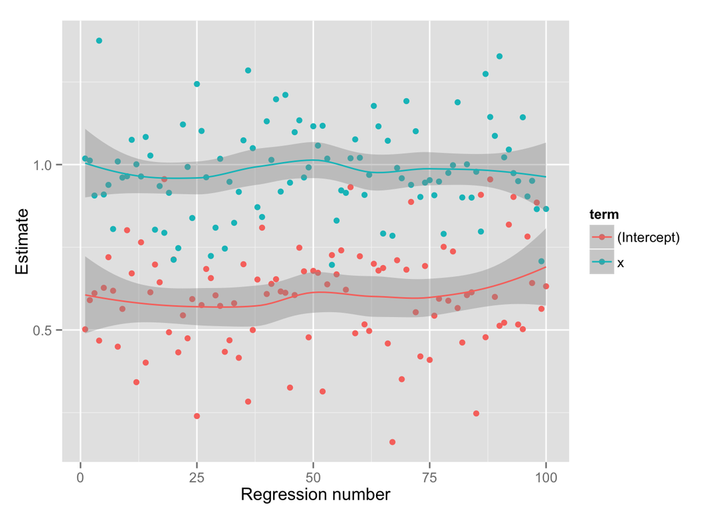

```r
qplot(i, estimate, color = term, data = results,
                                    geom = c("point","smooth" ),
                                    ylab = "Estimate",
                                    xlab = "Regression number")
```

Get thigns looking nicer by renaming term -> Term and changing x -> Beta and (Intercept) -> “Intercept”

```
## geom_smooth: method="auto" and size of largest group is <1000, so using loess. Use 'method = x' to change the smoothing method.
```

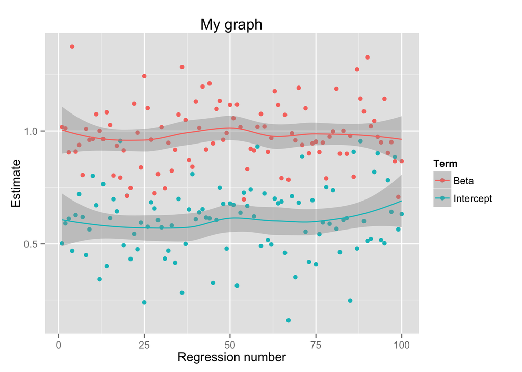

```r
results <- results %>%
  rename(Term = term)

results$Term <- ifelse(results$Term == "x", "Beta",results$Term)
results$Term <- ifelse(results$Term == "(Intercept)", "Intercept",results$Term)

qplot(i, estimate, color = Term, data = results,
                                    geom = c("point","smooth" ),
                                    ylab = "Estimate",
                                    xlab = "Regression number",
                                    main = "My graph")
```

Histograms and density plot

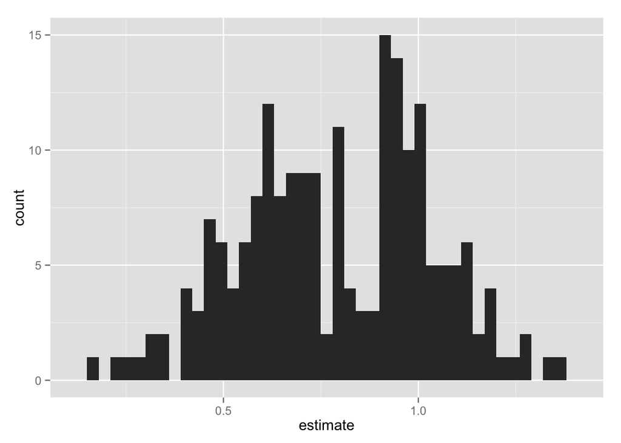

```r
qplot(estimate, data=results, binwidth=0.03)
```

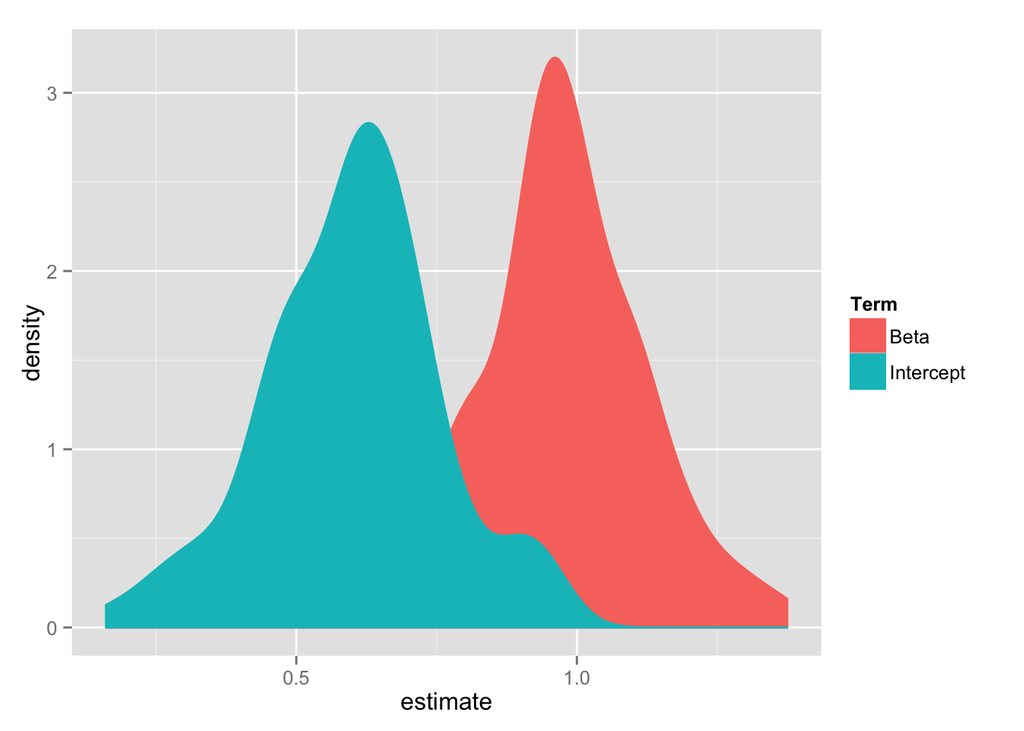

```r
qplot(estimate, data=results, binwidth=0.03, geom="density", fill=Term, color=Term)
```

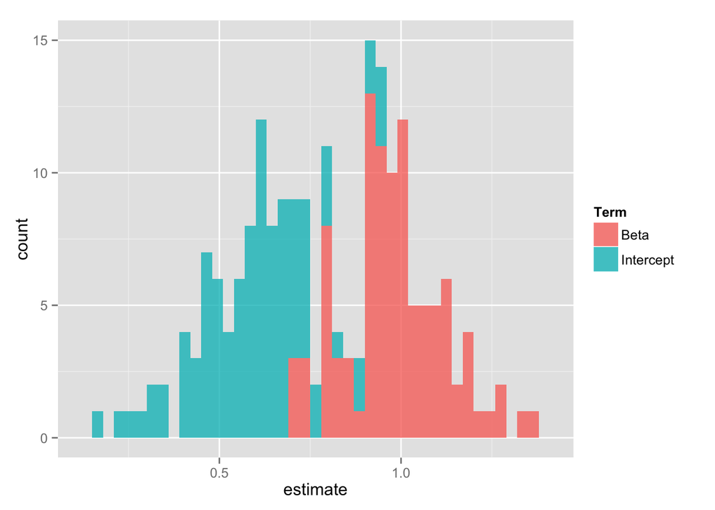

```r
qplot(estimate, data=results, fill = Term, binwidth=0.03, alpha = I(0.8))
```

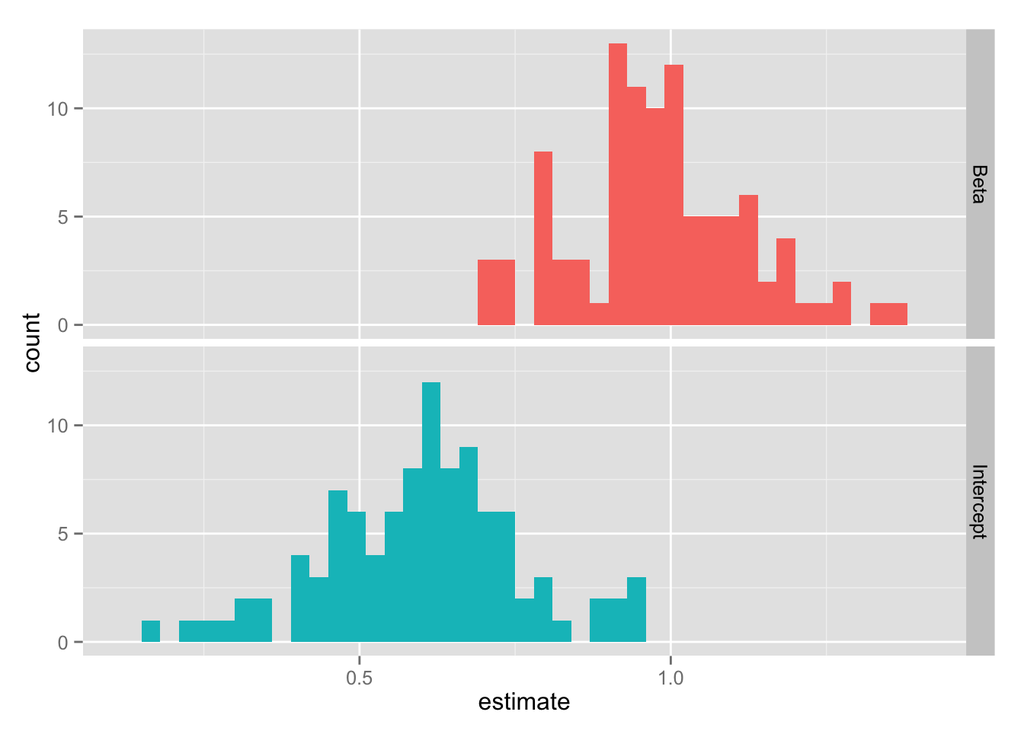

```r
qplot(estimate, data=results, fill = Term, binwidth=0.03, facets = Term~.) + theme(legend.position = "none")
```

```r
a <-  results %>%
        select(i,Term,estimate) %>%
          spread(Term,estimate)
```

Scatter plots

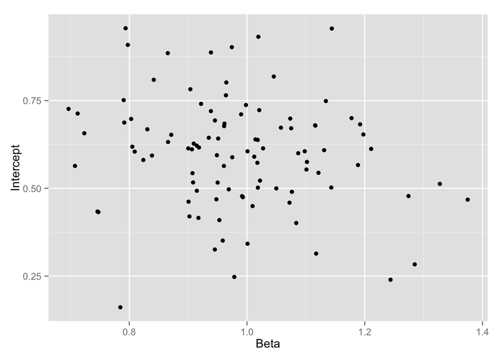

```r
qplot(Beta,Intercept,data=a)
```

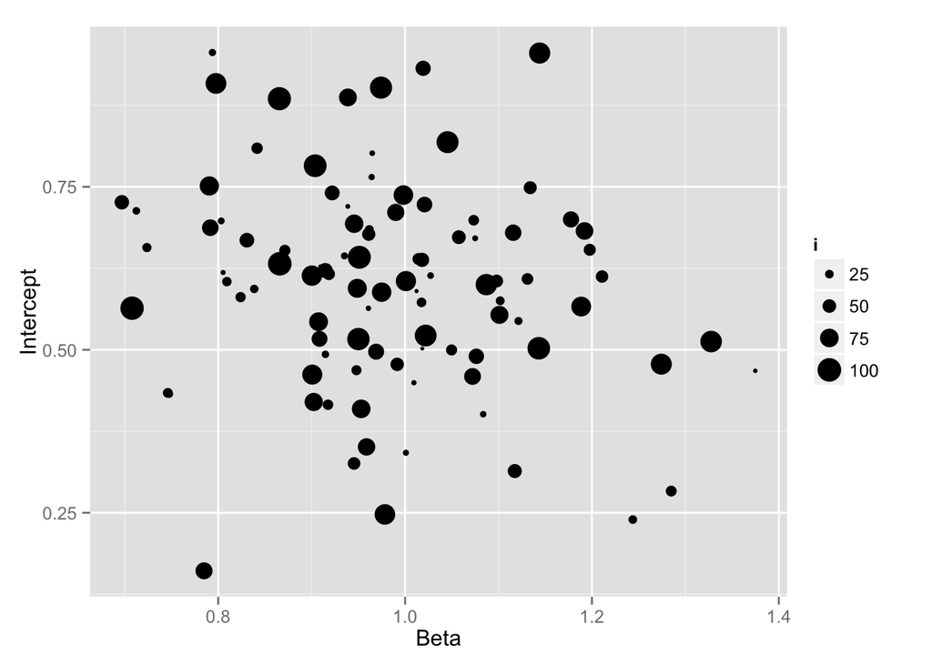

```r
qplot(Beta,Intercept,data=a,size=i)
```